# Веб-аналитика сервиса по продаже билетов

#### Lifetime Value: summary

Средний показатель LTV пользователя через 6 месяцев составляет 8.13 у.е.

Хотя за первые месяцы использование сервиса пользователи прикладных устройств приносят больше денег, после второго месяца рост их суммарной прибыли от них начинает замедляться и почти останавливается, тогда как пользователи десктопов остаются активными дольше и уже после 3-го месяца принесенная ими в пересчете на человека суммарная прибыль начинает значительно превышать прибыль от пользователей портативных устройств.

Показатель LTV для пользователей, попавших на сайт по каналам 1 и 2 рекламных источников выше и растет быстрее с увеличением времени жизни, чем для других рекламных источников.

## Метрики маркетинга

### Траты на маркетинг

```python
all_costs = costs['costs'].sum()
print('Всего на привлечение пользователей было потрачено {:.0f}'.format(all_costs))
```

```
Всего на привлечение пользователей было потрачено 329132
```

```python
costs['source_id'].unique()
```

```
array([ 1,  2,  3,  4,  5,  9, 10])
```

```python
# Траты на каждый источник

costs_by_source = costs.groupby('source_id').agg({'costs' : 'sum'})
costs_by_source
```

| source_id | costs |
| --- | --- |
| 1 | 20833.27 |
| 2 | 42806.04 |
| 3 | 141321.63 |
| 4 | 61073.60 |
| 5 | 51757.10 |
| 9 | 5517.49 |
| 10 | 5822.49 |

```python
#И в процентах от общих трат

(costs_by_source / all_costs) * 100
```

| source_id | costs |
| --- | --- |
| 1 | 6.329769 |
| 2 | 13.005751 |
| 3 | 42.937725 |
| 4 | 18.555981 |
| 5 | 15.725350 |
| 9 | 1.676378 |
| 10 | 1.769046 |

```python
# Траты по месяцам

costs_by_month = costs.groupby('payment_month')['costs'].sum()
costs_by_month
```

```
payment_month
2017-06-01    18015.00
2017-07-01    18240.59
2017-08-01    14790.54
2017-09-01    24368.91
2017-10-01    36322.88
2017-11-01    37907.88
2017-12-01    38315.35
2018-01-01    33518.52
2018-02-01    32723.03
2018-03-01    30415.27
2018-04-01    22289.38
2018-05-01    22224.27
Name: costs, dtype: float64
```

#### Траты на маркетинг: summary

Всего на привлечение покупателей было потрачено 329132.

Из них 43% на третий рекламный источник, 18.5 и 15.7 на 4 и 5 источники соответственно, на остальные -- меньше. Больше всего денег на маркетинг расходовалось в ноябре и декабре, меньше всего -- в летние месяцы.

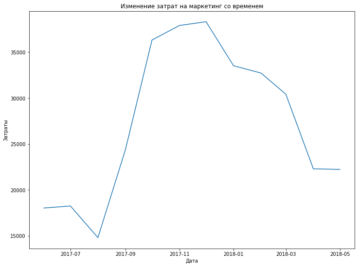

```python
vis = costs_by_month.reset_index()
plt.figure(figsize=(12, 9))
sns.lineplot(vis['payment_month'], vis['costs'])
plt.ylabel('Затраты')
plt.xlabel('Дата')
plt.title('Изменение затрат на маркетинг со временем')
plt.show()
```

### Стоймость привлечения покупателя (CAC)

```python
# Считаем количество покупателей, впервые зашедших на сайт по каждому из рекламных источников

buyers_by_source = orders.groupby('attributed_source')['uid'].count()
buyers_by_source.columns = ['n_buyers']
```

```python
buyer_source_costs = costs_by_source.join(buyers_by_source)
```

```python
buyer_source_costs
```

| source_id | costs | uid |
| --- | --- | --- |
| 1 | 20833.27 | 5182 |
| 2 | 42806.04 | 6561 |
| 3 | 141321.63 | 13370 |
| 4 | 61073.60 | 13045 |
| 5 | 51757.10 | 9767 |
| 9 | 5517.49 | 1703 |
| 10 | 5822.49 | 1598 |

```python
cac_by_source = buyer_source_costs['costs'] / buyer_source_costs['uid']
cac_by_source
```

```
source_id
1      4.020315
2      6.524316
3     10.570055
4      4.681763
5      5.299181
9      3.239865
10     3.643611
dtype: float64
```

```python
cac_by_source.mean()
```

```
5.4255864737186155
```

#### Стоймость привлечения покупателя: summary

Дороже всего обходится привлечения покупателя через третий рекламный источник (10.57), на втором месте по затратности рекламный источник 2 (6.52), дешевле всего обходится привлечение клиентов через 9 и 10 рекламные источники (3.23 и 3.64).

### Окупаемость расходов (ROI)

```python
costs_by_month = costs.groupby('payment_month')['costs'].sum()
costs_by_month
```

```
payment_month
2017-06-01    18015.00
2017-07-01    18240.59
2017-08-01    14790.54
2017-09-01    24368.91
2017-10-01    36322.88
2017-11-01    37907.88
2017-12-01    38315.35
2018-01-01    33518.52
2018-02-01    32723.03
2018-03-01    30415.27
2018-04-01    22289.38
2018-05-01    22224.27
Name: costs, dtype: float64
```

```python
costs_by_month = costs_by_month.reset_index()
costs_by_month['payment_month'] = costs_by_month['payment_month'].dt.to_period('M')
```

```python
# Добавляем в датафрейм с когортами costs, cac, roi

roi_cohorts = order_cohorts.merge(costs_by_month, left_on='cohort_by_order', right_on='payment_month')
roi_cohorts['cac'] = roi_cohorts['costs'] / roi_cohorts['n_buyers']
```

```python
roi_cohorts['roi'] = roi_cohorts['ltv'] / roi_cohorts['cac']
```

```python
roi_cohorts
```

|  | order_month | cohort_by_order | revenue | n_buyers | age | ltv | payment_month | costs | cac | roi |
| --- | --- | --- | --- | --- | --- | --- | --- | --- | --- | --- |
| 0 | 2017-06-01 | 2017-06 | 9834.34 | 2023 | 0 | 4.861265 | 2017-06 | 18015.00 | 8.905091 | 0.545897 |
| 1 | 2017-07-01 | 2017-06 | 986.64 | 2023 | 1 | 0.487711 | 2017-06 | 18015.00 | 8.905091 | 0.054768 |
| 2 | 2017-08-01 | 2017-06 | 900.01 | 2023 | 2 | 0.444889 | 2017-06 | 18015.00 | 8.905091 | 0.049959 |
| 3 | 2017-09-01 | 2017-06 | 1931.30 | 2023 | 3 | 0.954671 | 2017-06 | 18015.00 | 8.905091 | 0.107205 |
| 4 | 2017-10-01 | 2017-06 | 2068.58 | 2023 | 4 | 1.022531 | 2017-06 | 18015.00 | 8.905091 | 0.114825 |
| ... | ... | ... | ... | ... | ... | ... | ... | ... | ... | ... |
| 73 | 2018-04-01 | 2018-03 | 1069.30 | 3533 | 1 | 0.302661 | 2018-03 | 30415.27 | 8.608907 | 0.035157 |
| 74 | 2018-05-01 | 2018-03 | 1117.62 | 3533 | 2 | 0.316337 | 2018-03 | 30415.27 | 8.608907 | 0.036745 |
| 75 | 2018-04-01 | 2018-04 | 10827.01 | 2276 | 0 | 4.757034 | 2018-04 | 22289.38 | 9.793225 | 0.485747 |
| 76 | 2018-05-01 | 2018-04 | 1211.87 | 2276 | 1 | 0.532456 | 2018-04 | 22289.38 | 9.793225 | 0.054370 |
| 77 | 2018-05-01 | 2018-05 | 14191.79 | 2988 | 0 | 4.749595 | 2018-05 | 22224.27 | 7.437841 | 0.638572 |

78 rows × 10 columns

```python
roi_table = roi_cohorts.pivot_table(index='cohort_by_order', columns='age', values='roi')
roi_table = roi_table.cumsum(axis=1).round(2)
roi_table
```

| age cohort_by_order | 0 | 1 | 2 | 3 | 4 | 5 | 6 | 7 | 8 | 9 | 10 | 11 |
| --- | --- | --- | --- | --- | --- | --- | --- | --- | --- | --- | --- | --- |
| 2017-06 | 0.55 | 0.60 | 0.65 | 0.76 | 0.87 | 0.96 | 1.06 | 1.13 | 1.19 | 1.26 | 1.32 | 1.35 |
| 2017-07 | 0.65 | 0.69 | 0.75 | 0.79 | 0.81 | 0.83 | 0.84 | 0.86 | 0.88 | 0.89 | 0.91 | NaN |
| 2017-08 | 0.50 | 0.55 | 0.59 | 0.62 | 0.67 | 0.70 | 0.72 | 0.76 | 0.78 | 0.80 | NaN | NaN |
| 2017-09 | 0.61 | 0.73 | 0.78 | 1.20 | 1.24 | 1.31 | 1.39 | 1.41 | 1.43 | NaN | NaN | NaN |
| 2017-10 | 0.61 | 0.68 | 0.71 | 0.73 | 0.74 | 0.76 | 0.77 | 0.78 | NaN | NaN | NaN | NaN |
| 2017-11 | 0.57 | 0.61 | 0.64 | 0.67 | 0.69 | 0.69 | 0.71 | NaN | NaN | NaN | NaN | NaN |
| 2017-12 | 0.56 | 0.59 | 0.69 | 0.82 | 0.85 | 0.89 | NaN | NaN | NaN | NaN | NaN | NaN |
| 2018-01 | 0.42 | 0.45 | 0.49 | 0.50 | 0.51 | NaN | NaN | NaN | NaN | NaN | NaN | NaN |
| 2018-02 | 0.48 | 0.51 | 0.52 | 0.53 | NaN | NaN | NaN | NaN | NaN | NaN | NaN | NaN |
| 2018-03 | 0.57 | 0.61 | 0.65 | NaN | NaN | NaN | NaN | NaN | NaN | NaN | NaN | NaN |
| 2018-04 | 0.49 | 0.54 | NaN | NaN | NaN | NaN | NaN | NaN | NaN | NaN | NaN | NaN |
| 2018-05 | 0.64 | NaN | NaN | NaN | NaN | NaN | NaN | NaN | NaN | NaN | NaN | NaN |

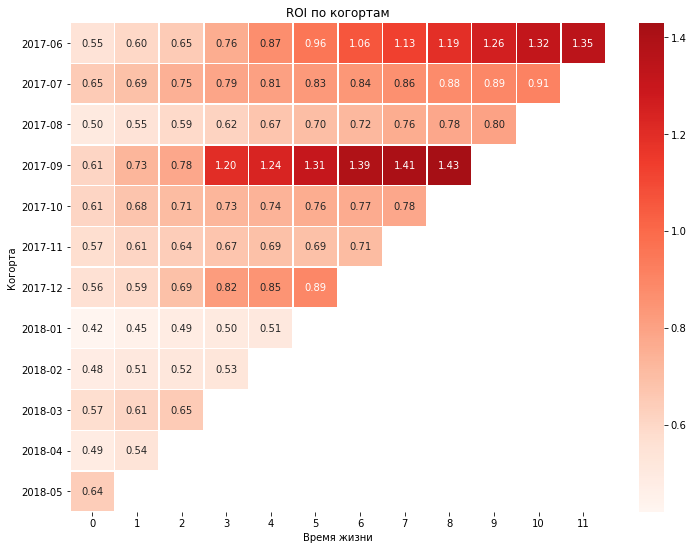

```python
plt.figure(figsize=(12, 9))
sns.heatmap(roi_table, center=1, cmap='Reds', annot=True, fmt='.2f', linewidths=0.5, linecolor='white')
plt.title('ROI по когортам')
plt.ylabel('Когорта')
plt.xlabel('Время жизни')
plt.show()
```

```python
#Смотрим, через какой промежуток времени в среднем окупаются расходы

roi_table.mean(axis=0)
```

```
age
0     0.554167
1     0.596364
2     0.647000
3     0.735556
4     0.797500
5     0.877143
6     0.915000
7     0.988000
8     1.070000
9     0.983333
10    1.115000
11    1.350000
dtype: float64
```

```python
# ROI по источникам

roi_by_sources = ltv_by_sources.div(cac_by_source, axis=0).cumsum(axis=1)
roi_by_sources
```

| age | 0 | 1 | 2 | 3 | 4 | 5 | 6 | 7 | 8 | 9 | 10 | 11 |
| --- | --- | --- | --- | --- | --- | --- | --- | --- | --- | --- | --- | --- |
| 1.0 | 0.895879 | 1.026131 | 1.138880 | 1.224543 | 1.275271 | 1.306491 | 1.336867 | 1.383979 | 1.424930 | 1.445959 | 1.462422 | 1.477570 |
| 2.0 | 0.557951 | 0.677413 | 0.810719 | 0.942892 | 1.000295 | 1.043942 | 1.073929 | 1.090044 | 1.100969 | 1.106438 | 1.116278 | 1.118542 |
| 3.0 | 0.333314 | 0.352866 | 0.363426 | 0.370605 | 0.375836 | 0.379407 | 0.381398 | 0.383092 | 0.384228 | 0.384780 | 0.385109 | 0.385234 |
| 4.0 | 0.772777 | 0.805405 | 0.821897 | 0.844580 | 0.862091 | 0.881521 | 0.910580 | 0.917569 | 0.920640 | 0.927276 | 0.936042 | 0.936616 |
| 5.0 | 0.663762 | 0.696521 | 0.722341 | 0.929008 | 0.958464 | 0.993291 | 1.012445 | 1.026318 | 1.036156 | 1.047885 | 1.049847 | 1.050920 |
| 7.0 | NaN | NaN | NaN | NaN | NaN | NaN | NaN | NaN | NaN | NaN | NaN | NaN |
| 9.0 | 0.793689 | 0.855998 | 0.909185 | 0.954173 | 0.981022 | 1.006233 | 1.027864 | 1.044083 | 1.069997 | 1.073396 | 1.075090 | NaN |
| 10.0 | 0.735941 | 0.765374 | 0.790344 | 0.802109 | 0.806203 | 0.808486 | 0.810406 | 0.813205 | 0.813782 | 0.814359 | NaN | NaN |

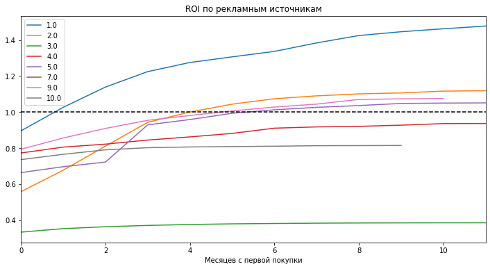

```python
roi_by_sources.T.plot(figsize=(12,6))
plt.axhline(y=1, label='Уровень окупаемость', color='black', linestyle='--')
plt.title('ROI по рекламным источникам')
plt.xlabel('Месяцев с первой покупки')
plt.show()
```

#### Окупаемость расходов: summary

В среднем, маркетинговые расходы на привлечение пользователя окупаются и он начинает приносить прибыль только на 9-й месяц использования сервиса (операционные расходы по условию не учитываем).

Быстрее всего окупаются затраты на первый рекламный источник (на 2-й месяц), на 5-й месяц окупаются затраты на второй рекламный источник, на 6-й месяц -- на рекламный источник 9, на 7-й -- на рекламный источник 5. Затраты на привлечение покупателей через остальные рекламные источники не окупились за весь рассмотренный период (1 год). Самым убыточным в этом плане оказались вложения в рекламный источник 3, затраты на него к 12-му месяцу окупаются только на 40%.

## Основные метрики: summary по шагу

Продукт

- Сессий в день: 889.
- DAU = 818.
- WAU = 5247.
- MAU = 20956.
- Средняя продолжительность сессии: 12 минут.
- 22% людей, зашедших на сайт, продолжают пользоваться им в дальнейшем.

Продажи

- 142 заказа в день.
- 17% пользователей делают хотя бы один заказ.
- Средний чек: 4.98.
- Медианный чек: 2.44.
- LTV за 6 месяцев: 8.13.

Маркетинг

- CAC = 5.4.
- Расходы на привлечение покупателя окупаются через 9 месяцев.

# Шаг 3. Выводы и рекомендации

На данный момент, больше всего средств тратится на привлечение покупателей через рекламную платформу 3 (43% от всех маркетинговых расходов), при этом она является самым дорогим в пересчете на привлечение одного покупателя рекламным источником (каждый покупатель здесь стоит больше 10 у.е., что более чем в полтора раза превышает величину следующего показателя). При этом LTV покупателей, привлеченных по этому каналу, для любой продолжительности жизни ниже, чем LTV клиентов, привлеченных почти по любому другому каналу. В результате, за 12 месяцев расходы на привлечение покупателя окупаются только на 40%. С 4-й рекламной платформой наблюдается похожая ситуация: в нее так же вкладывается неоправданно много средств, а инвестии не возвращаются и через 12 месяцев. Также не возвращаются инвестиции и в 10 рекламную платформу, но объем их в любом случае незначителен.

Добиться увеличения прибыли можно значительно сократив инвестиции на 3 и 4 платформу и ивестировав их в привлечение покупателей через 1 и 2 рекламные платформы. Маркетинговые расходы на первую платформу окупаются уже на второй месяц, благодаря низкой стоймости привлечения покупателя (4 у.е.). Расходы на вторую платформу окупаются на 5-й месяц, но при этом клиенты, пришедшие по этому каналу, отличаются самой высокой лояльностью и дольше всех остальных продолжают пользоваться сервисом.

Расходы на 5 рекламную платформу окупаются только на 7 месяц, при этом, учитывая низкий показатель ROI, несмотря на то, что она преодолевает порог окупаемости, прибыли пришедшие с нее клиенты почти не приносят. Расходы на 9-ю платформу тоже окупатются только через 6 месяцев, но при этом для нее ниже, по сравнению с 5 источником, стооймость привлечения покупателя с одной стороны, и выше лояльность привлеченных клиентов с другой стороны, поэтому 9-я рекламная платформа является более удачным способ инвестирования, чем платформа 5, хотя сейчас в нее вкладывается 1.7% от общих маркетинговых расходов, а в платформу 5 -- 15.7%.

Рекомендации.